# Pengaruh Popularitas Film terhadap Total Pendapatan Rental

Finalia Salwa Zakiyah Kista | M0725065

2026-05-24

# 1 Pendahuluan

Pada laporan ini dilakukan analisis untuk mengetahui film dengan pendapatan tertinggi berdasarkan transaksi rental pelanggan. Pengambilan data dilakukan menggunakan SQL melalui koneksi database MySQL, kemudian data dianalisis dan divisualisasikan menggunakan bahasa R dengan bantuan package ggplot2. Selain itu, laporan disusun dalam format HTML menggunakan RMarkdown dengan tambahan kustomisasi CSS dan persamaan matematis menggunakan LaTeX agar tampilan laporan menjadi lebih menarik dan terstruktur.

Database Sakila merupakan database contoh yang disediakan oleh MySQL untuk simulasi sistem rental film. Dataset ini memiliki berbagai tabel yang saling berelasi seperti film, customer, rental, payment, dan category.

Analisis dilakukan menggunakan:

1. SQL untuk pengambilan data
2. R untuk analisis data
3. ggplot2 untuk visualisasi data

# 2 Insight Analisis

Insight yang diambil pada analisis ini adalah **mengetahui hubungan antara popularitas film dengan total pendapatan rental** pada database Sakila. Popularitas film diukur berdasarkan jumlah transaksi rental, sedangkan pendapatan dihitung dari total pembayaran pelanggan terhadap film tersebut.

Melalui analisis ini dapat diketahui film-film yang paling diminati pelanggan dan kontribusinya terhadap pendapatan rental. Hasil analisis dapat digunakan sebagai bahan evaluasi bisnis maupun strategi promosi film.

# 3 Penggunaan library

```r
library(DBI)
library(RMySQL)
library(dplyr)
```

```r
library(ggplot2)
library(knitr)
library(odbc)
```

# 4 Koneksi Database

```r
con = dbConnect(odbc(),
          Driver = "MySQL ODBC 8.0 ANSI Driver",
          Server = "127.0.0.1",
          UID = "root",
          PWD = "Finalia1737",
          Port = 3306,
          Database = "sakila")

dbListTables(con)
```

```
##  [1] "actor"                      "actor_info"
##  [3] "address"                    "category"
##  [5] "city"                       "country"
##  [7] "customer"                   "customer_list"
##  [9] "film"                       "film_actor"
## [11] "film_category"              "film_list"
## [13] "film_text"                  "inventory"
## [15] "language"                   "nicer_but_slower_film_list"
## [17] "payment"                    "rental"
## [19] "sales_by_film_category"     "sales_by_store"
## [21] "staff"                      "staff_list"
## [23] "store"
```

# 5 Pengambilan Data

```r
query = "SELECT f.title AS judul_film,
    COUNT(r.rental_id) AS jumlah_rental,
    SUM(p.amount) AS total_pendapatan
FROM film f
JOIN inventory i
    ON f.film_id = i.film_id
JOIN rental r
    ON i.inventory_id = r.inventory_id
JOIN payment p
    ON r.rental_id = p.rental_id
GROUP BY judul_film
ORDER BY total_pendapatan DESC
LIMIT 10;
"
```

## 5.1 Top 10 Film dengan Pendapatan Tertinggi

```r
film_income <- dbGetQuery(con, query)

film_income
```

```
##           judul_film jumlah_rental total_pendapatan
## 1   TELEGRAPH VOYAGE            27           231.73
## 2          WIFE TURN            31           223.69
## 3          ZORRO ARK            31           214.69
## 4  GOODFELLAS SALUTE            31           209.69
## 5     SATURDAY LAMBS            28           204.72
## 6        TITANS JERK            29           201.71
## 7       TORQUE BOUND            27           198.72
## 8        HARRY IDAHO            30           195.70
## 9     INNOCENT USUAL            26           191.74
## 10     HUSTLER PARTY            22           190.78
```

# 6 Menampilkan Tabel Hasil Analisis

```r
kable(
  film_income,
  caption = "Top 10 Film dengan Pendapatan Tertinggi"
)
```

Top 10 Film dengan Pendapatan Tertinggi

| judul_film | jumlah_rental | total_pendapatan |
| --- | --- | --- |
| TELEGRAPH VOYAGE | 27 | 231.73 |
| WIFE TURN | 31 | 223.69 |
| ZORRO ARK | 31 | 214.69 |
| GOODFELLAS SALUTE | 31 | 209.69 |
| SATURDAY LAMBS | 28 | 204.72 |
| TITANS JERK | 29 | 201.71 |
| TORQUE BOUND | 27 | 198.72 |
| HARRY IDAHO | 30 | 195.70 |
| INNOCENT USUAL | 26 | 191.74 |
| HUSTLER PARTY | 22 | 190.78 |

# 7 Visualisasi Data

## 7.1 Bar Chart Pendapatan Film

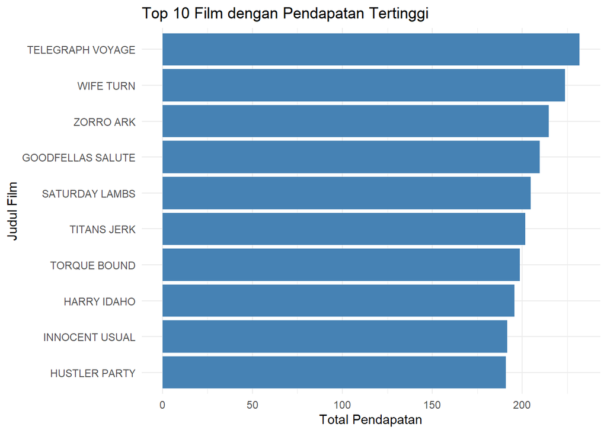

```r
ggplot(film_income,
       aes(x = reorder(judul_film, total_pendapatan),
           y = total_pendapatan)) +
  geom_bar(
    stat = "identity",
    fill = "steelblue") +
  coord_flip() +
  labs(
    title = "Top 10 Film dengan Pendapatan Tertinggi",
    x = "Judul Film",
    y = "Total Pendapatan") +
  theme_minimal()
```

[output not shown]

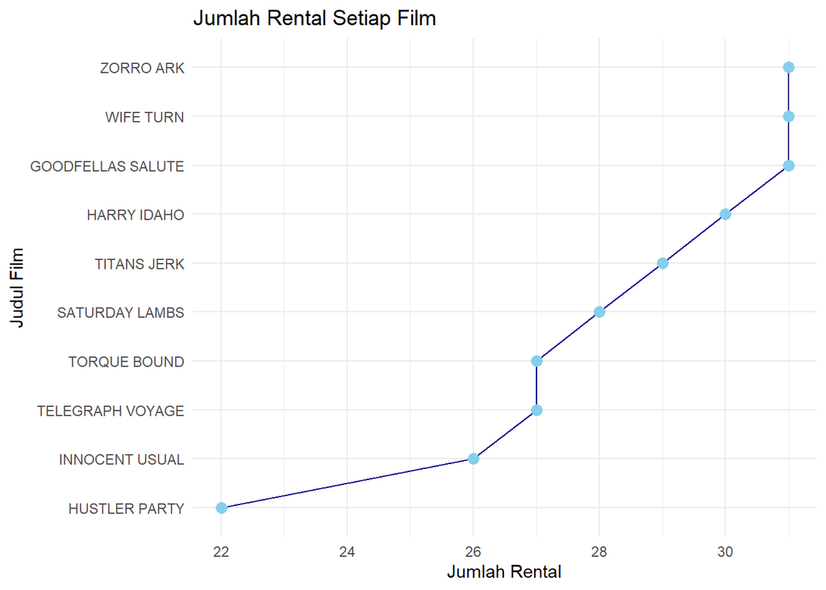

```r
ggplot(film_income,
       aes(x = reorder(judul_film, jumlah_rental),
           y = jumlah_rental,
           group = 1)) +
  geom_line(color = "darkblue") +
  geom_point(
    color = "skyblue",
    size = 3) +
  coord_flip() +
  labs(
    title = "Jumlah Rental Setiap Film",
    x = "Judul Film",
    y = "Jumlah Rental") +
  theme_minimal()
```

# 8 Analisis Tambahan

## 8.1 Menghitung Rata-rata Pendapatan

```r
mean(film_income$total_pendapatan)
```

```
## [1] 206.317
```

## 8.2 Menampilkan Film dengan Pendapatan Tertinggi

```r
film_tertinggi <- film_income %>%
  slice_max(total_pendapatan, n = 1)

film_tertinggi
```

```
##         judul_film jumlah_rental total_pendapatan
## 1 TELEGRAPH VOYAGE            27           231.73
```

# 9 Persamaan Matematis Menggunakan LaTeX

Persamaan pendapatan total:
$$Total\ Pendapatan = \sum_{i=1}^{n} payment_i$$

Keterangan:

- $payment_i$ adalah pembayaran ke-$i$
- $n$ adalah jumlah transaksi rental

Persamaan rata-rata pendapatan:
$$\bar{x} = \frac{\sum x_i}{n}$$

Keterangan:

- $\bar{x}$ = rata-rata pendapatan
- $x_i$ = data pendapatan
- $n$ = jumlah data

# 10 Interpretasi Hasil Analisis

Visualisasi line chart dapat dilihat pola dari film-film dengan jumlah rental yang lebih tinggi dibandingkan film lainnya. Titik-titik pada garis menunjukkan jumlah transaksi rental yang terjadi pada setiap film. Semakin tinggi posisi titik pada grafik, maka semakin besar jumlah penyewaan film tersebut. Line chart ini memberikan gambaran mengenai tingkat popularitas film berdasarkan frekuensi rental. Informasi tersebut dapat digunakan untuk mengetahui film yang paling diminati pelanggan dan membantu pengambilan keputusan dalam pengelolaan bisnis rental film.

# 11 Kesimpulan

# 12 Menutup Koneksi Database

```r
dbDisconnect(con)
```